# results and discussion outline

## 1. Model output compared to data

**add columns of median 2016 resistance and resilience for each species, each climate scenario - see which is most sensitive to the changes**

| Tree | LAI range (Alonzo et al. 2016) | median modelled LAI | Filtered parameter sets (n) |
| --- | --- | --- | --- |
| QUAG | 3.33 - 5.21 | 3.84 | 366 |
| EUGL | 4.22 - 6.29 | 4.47 | 153 |
| PICA | 3.82 - 9.02 | 4.34 | 404 |
| PIUN | 2.82 - 5.5 | 3.95 | 533 |
| PLRA | 3.75 - 6.14 | 4.12 | 217 |

Model outputs of LAI for the year 2011 fell within the range of estimated LAI for each species, although the median of the parameter ensembles is slightly lower than the median of the remotely sensed data. In Kendall rank correlation tests, all of the tree species show positive association between the modelled and observed LAI values, with significant p-values.

We used percent changes in NDVI to compare with changes in LAI in the model. We had NDVI data from 2011, a pre-drought wet year, 2014, the warmest year of the drought, and 2017, a wet year following the drought period.

Parameter ensembles were filtered to be within the range of percent differences between 2011-2014 and 2011-2017. To test for similarities between the two sets of percent differences, the modelled outputs were randomly sampled from each tree species parameter ensemble to 50 sets, and tested against 50 percent differences in NDVI using a Mann-Whitney test. The results were variable across tree species: QUAG, PICA, and PLRA had significant differences in the decline in LAI / NDVI from 2011-2014. Only EUGL and PLRA show significant differences for the 2011-2017 percent differences. Despite these differences in medians, the results for each tree species parameter ensemble fall within the range of the data.

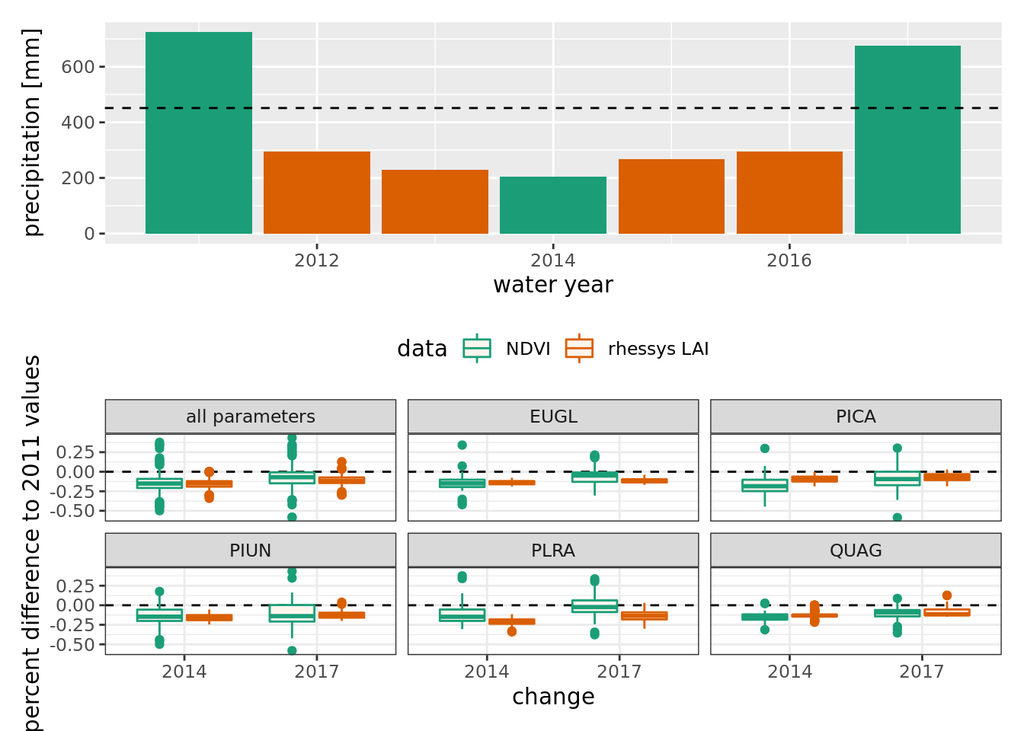

In the above plot, the variation in the NDVI data is due to different trees (of the same species) within the dataset. The variation in the model LAI is due to parameter uncertainty.